# Question

A thief is filling her backpack with two types of valuable substances. She can carry up to 30 kg, and her backpack can fit up to 10 liters.

Each bag of $X$ has a weight of 0.1 kg, volume of 0.01 L, and value of 0.5 thousand USD.

Each bag of $Y$ has a weight of 1 kg, volume of 0.4 L, and value of 9 thousand USD.

There is no requirement to take full bags, so the thief can opt for a fraction of a bag.

How many bags of each should the thief take to maximize her profit?

# Solution

The thief should take 66.67 bags of $X$ and 23.33 bags of $Y$. We can use linear programming to see this.

We write a weight inequality.
$$0.1x+1y \le 30$$
We write a volume inequality.
$$0.01x+0.4y \le 10$$
We graph the two inequalities, shading the feasible region.

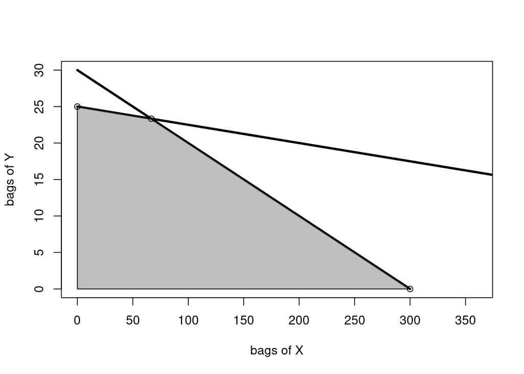

There are three vertices of interest.
$$(0,25)$$
$$(66.67,23.33)$$
$$(300,0)$$

We write a profit function (the objective function).
$$P(x,y) = 0.5x+9y$$

We determine the profits.
$$P(0,25)=225$$
$$P(66.67,23.33)=243.33$$
$$P(300,0)=150$$
Thus, the thief should take 66.67 bags of $X$ and 23.33 bags of $Y$.

# Meta-information

extype: string exsolution: nil exname: nonlinear_system_parabola_line_0_solution